# Risk Factor Analysis

## Outcome Variable

**Outcome Variable:** wasted

## Predictor Variables

**Intervention Variable:** vagbrth

**Adjustment Set:**

- arm
- sex
- W_mage
- meducyrs
- feducyrs
- hhwealth_quart
- W_mhtcm
- W_mwtkg
- W_mbmi
- single
- W_nrooms
- brthmon
- W_parity
- impfloor
- delta_W_mage
- delta_meducyrs
- delta_feducyrs
- delta_hhwealth_quart
- delta_W_mhtcm
- delta_W_mwtkg
- delta_W_mbmi
- delta_single
- delta_W_nrooms
- delta_brthmon
- delta_W_parity
- delta_impfloor

## Stratifying Variables

The analysis was stratified on these variable(s):

- agecat
- studyid
- country

## Data Summary

| agecat | studyid | country | vagbrth | wasted | n_cell | n |
| --- | --- | --- | --- | --- | --- | --- |
| Birth | CMC-V-BCS-2002 | INDIA | 0 | 0 | 8 | 86 |
| Birth | CMC-V-BCS-2002 | INDIA | 0 | 1 | 2 | 86 |
| Birth | CMC-V-BCS-2002 | INDIA | 1 | 0 | 67 | 86 |
| Birth | CMC-V-BCS-2002 | INDIA | 1 | 1 | 9 | 86 |
| Birth | IRC | INDIA | 0 | 0 | 45 | 343 |
| Birth | IRC | INDIA | 0 | 1 | 21 | 343 |
| Birth | IRC | INDIA | 1 | 0 | 206 | 343 |
| Birth | IRC | INDIA | 1 | 1 | 71 | 343 |
| Birth | JiVitA-3 | BANGLADESH | 0 | 0 | 398 | 17985 |
| Birth | JiVitA-3 | BANGLADESH | 0 | 1 | 102 | 17985 |
| Birth | JiVitA-3 | BANGLADESH | 1 | 0 | 15618 | 17985 |
| Birth | JiVitA-3 | BANGLADESH | 1 | 1 | 1867 | 17985 |
| Birth | JiVitA-4 | BANGLADESH | 0 | 0 | 57 | 2395 |
| Birth | JiVitA-4 | BANGLADESH | 0 | 1 | 14 | 2395 |
| Birth | JiVitA-4 | BANGLADESH | 1 | 0 | 2099 | 2395 |
| Birth | JiVitA-4 | BANGLADESH | 1 | 1 | 225 | 2395 |
| Birth | NIH-Crypto | BANGLADESH | 0 | 0 | 150 | 465 |
| Birth | NIH-Crypto | BANGLADESH | 0 | 1 | 34 | 465 |
| Birth | NIH-Crypto | BANGLADESH | 1 | 0 | 220 | 465 |
| Birth | NIH-Crypto | BANGLADESH | 1 | 1 | 61 | 465 |
| Birth | PROBIT | BELARUS | 0 | 0 | 1298 | 13817 |
| Birth | PROBIT | BELARUS | 0 | 1 | 293 | 13817 |
| Birth | PROBIT | BELARUS | 1 | 0 | 9613 | 13817 |
| Birth | PROBIT | BELARUS | 1 | 1 | 2613 | 13817 |
| Birth | PROVIDE | BANGLADESH | 0 | 0 | 85 | 532 |
| Birth | PROVIDE | BANGLADESH | 0 | 1 | 23 | 532 |
| Birth | PROVIDE | BANGLADESH | 1 | 0 | 330 | 532 |
| Birth | PROVIDE | BANGLADESH | 1 | 1 | 94 | 532 |
| Birth | ZVITAMBO | ZIMBABWE | 0 | 0 | 906 | 12814 |
| Birth | ZVITAMBO | ZIMBABWE | 0 | 1 | 194 | 12814 |

[output cut: 74 more lines]

The following strata were considered:

- agecat: 24 months, studyid: CMC-V-BCS-2002, country: INDIA
- agecat: 24 months, studyid: IRC, country: INDIA
- agecat: 24 months, studyid: JiVitA-3, country: BANGLADESH
- agecat: 24 months, studyid: JiVitA-4, country: BANGLADESH
- agecat: 24 months, studyid: NIH-Crypto, country: BANGLADESH
- agecat: 24 months, studyid: PROBIT, country: BELARUS
- agecat: 24 months, studyid: PROVIDE, country: BANGLADESH
- agecat: 24 months, studyid: TanzaniaChild2, country: TANZANIA, UNITED REPUBLIC OF
- agecat: 24 months, studyid: ZVITAMBO, country: ZIMBABWE
- agecat: 6 months, studyid: CMC-V-BCS-2002, country: INDIA
- agecat: 6 months, studyid: IRC, country: INDIA
- agecat: 6 months, studyid: JiVitA-3, country: BANGLADESH
- agecat: 6 months, studyid: JiVitA-4, country: BANGLADESH
- agecat: 6 months, studyid: NIH-Crypto, country: BANGLADESH
- agecat: 6 months, studyid: PROBIT, country: BELARUS
- agecat: 6 months, studyid: PROVIDE, country: BANGLADESH
- agecat: 6 months, studyid: TanzaniaChild2, country: TANZANIA, UNITED REPUBLIC OF
- agecat: 6 months, studyid: ZVITAMBO, country: ZIMBABWE
- agecat: Birth, studyid: CMC-V-BCS-2002, country: INDIA
- agecat: Birth, studyid: IRC, country: INDIA
- agecat: Birth, studyid: JiVitA-3, country: BANGLADESH
- agecat: Birth, studyid: JiVitA-4, country: BANGLADESH
- agecat: Birth, studyid: NIH-Crypto, country: BANGLADESH
- agecat: Birth, studyid: PROBIT, country: BELARUS
- agecat: Birth, studyid: PROVIDE, country: BANGLADESH
- agecat: Birth, studyid: ZVITAMBO, country: ZIMBABWE

### Dropped Strata

Some strata were dropped due to rare outcomes:

- agecat: Birth, studyid: CMC-V-BCS-2002, country: INDIA
- agecat: 6 months, studyid: CMC-V-BCS-2002, country: INDIA
- agecat: 6 months, studyid: NIH-Crypto, country: BANGLADESH
- agecat: 24 months, studyid: CMC-V-BCS-2002, country: INDIA
- agecat: 24 months, studyid: PROBIT, country: BELARUS
- agecat: 24 months, studyid: TanzaniaChild2, country: TANZANIA, UNITED REPUBLIC OF
- agecat: 24 months, studyid: ZVITAMBO, country: ZIMBABWE

## Methods Detail

We’re interested in the causal parameters $E[Y_a]$ for all values of $a \in \mathcal{A}$. These parameters represent the mean outcome if, possibly contrary to fact, we intervened to set all units to have $A=a$. Under the randomization and positivity assumptions, these are identified by the statistical parameters $\psi_a=E_W[E_{Y|A,W}(Y|A=a,W)]$. In addition, we’re interested in the mean of $Y$, $E[Y]$ under no intervention (the observed mean). We will estimate these parameters by using SuperLearner to fit the relevant likelihood factors – $E_{Y|A,W}(Y|A=a,W)$ and $p(A=a|W)$, and then updating our likelihood fit using a joint TMLE.

For unadjusted analyses ($W=\{\}$), initial likelihoods were estimated using Lrnr_glm to estimate the simple $E(Y|A)$ and Lrnr_mean to estimate $p(A)$. For adjusted analyses, a small library containing Lrnr_glmnet, Lrnr_xgboost, and Lrnr_mean was used.

Having estimated these parameters, we will then use the delta method to estimate relative risks and attributable risks relative to a prespecified baseline level of $A$.

# Results Detail

## Results Plots

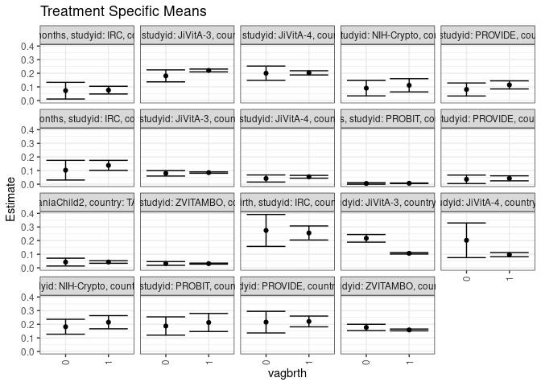

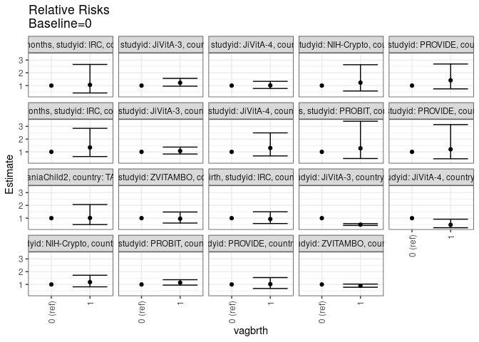

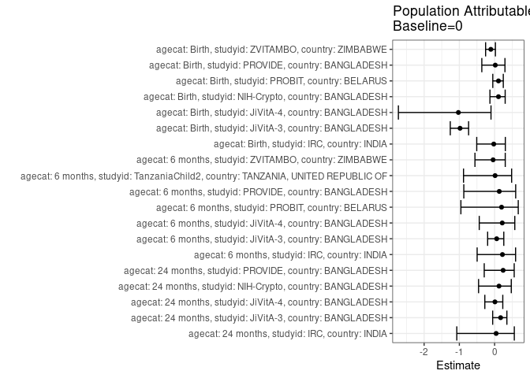

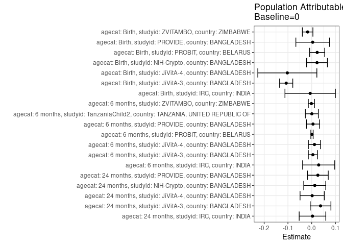

## Results Table

### Parameter: TSM

| agecat | studyid | country | intervention_level | baseline_level | estimate | ci_lower | ci_upper |
| --- | --- | --- | --- | --- | --- | --- | --- |
| Birth | IRC | INDIA | 0 | NA | 0.2746107 | 0.1574937 | 0.3917277 |
| Birth | IRC | INDIA | 1 | NA | 0.2560207 | 0.2043478 | 0.3076937 |
| Birth | JiVitA-3 | BANGLADESH | 0 | NA | 0.2168414 | 0.1888892 | 0.2447935 |
| Birth | JiVitA-3 | BANGLADESH | 1 | NA | 0.1067475 | 0.1015107 | 0.1119844 |
| Birth | JiVitA-4 | BANGLADESH | 0 | NA | 0.2023152 | 0.0752736 | 0.3293568 |
| Birth | JiVitA-4 | BANGLADESH | 1 | NA | 0.0968425 | 0.0814657 | 0.1122193 |
| Birth | NIH-Crypto | BANGLADESH | 0 | NA | 0.1818732 | 0.1272164 | 0.2365301 |
| Birth | NIH-Crypto | BANGLADESH | 1 | NA | 0.2149513 | 0.1666439 | 0.2632587 |
| Birth | PROBIT | BELARUS | 0 | NA | 0.1872035 | 0.1201304 | 0.2542767 |
| Birth | PROBIT | BELARUS | 1 | NA | 0.2132346 | 0.1470076 | 0.2794616 |
| Birth | PROVIDE | BANGLADESH | 0 | NA | 0.2157304 | 0.1363775 | 0.2950834 |
| Birth | PROVIDE | BANGLADESH | 1 | NA | 0.2207879 | 0.1813025 | 0.2602733 |
| Birth | ZVITAMBO | ZIMBABWE | 0 | NA | 0.1768775 | 0.1536624 | 0.2000927 |
| Birth | ZVITAMBO | ZIMBABWE | 1 | NA | 0.1585181 | 0.1519005 | 0.1651358 |
| 6 months | IRC | INDIA | 0 | NA | 0.1029412 | 0.0306257 | 0.1752567 |
| 6 months | IRC | INDIA | 1 | NA | 0.1382353 | 0.1015032 | 0.1749674 |
| 6 months | JiVitA-3 | BANGLADESH | 0 | NA | 0.0797559 | 0.0600326 | 0.0994792 |
| 6 months | JiVitA-3 | BANGLADESH | 1 | NA | 0.0852118 | 0.0803190 | 0.0901045 |
| 6 months | JiVitA-4 | BANGLADESH | 0 | NA | 0.0418920 | 0.0159874 | 0.0677967 |
| 6 months | JiVitA-4 | BANGLADESH | 1 | NA | 0.0545417 | 0.0442830 | 0.0648004 |
| 6 months | PROBIT | BELARUS | 0 | NA | 0.0055001 | 0.0000065 | 0.0109938 |
| 6 months | PROBIT | BELARUS | 1 | NA | 0.0070198 | 0.0054235 | 0.0086160 |
| 6 months | PROVIDE | BANGLADESH | 0 | NA | 0.0359712 | 0.0049882 | 0.0669542 |
| 6 months | PROVIDE | BANGLADESH | 1 | NA | 0.0431034 | 0.0246091 | 0.0615978 |
| 6 months | TanzaniaChild2 | TANZANIA, UNITED REPUBLIC OF | 0 | NA | 0.0423280 | 0.0136171 | 0.0710390 |
| 6 months | TanzaniaChild2 | TANZANIA, UNITED REPUBLIC OF | 1 | NA | 0.0429752 | 0.0336429 | 0.0523075 |
| 6 months | ZVITAMBO | ZIMBABWE | 0 | NA | 0.0323734 | 0.0187646 | 0.0459821 |
| 6 months | ZVITAMBO | ZIMBABWE | 1 | NA | 0.0309599 | 0.0270883 | 0.0348315 |
| 24 months | IRC | INDIA | 0 | NA | 0.0724638 | 0.0112173 | 0.1337102 |
| 24 months | IRC | INDIA | 1 | NA | 0.0764706 | 0.0481884 | 0.1047528 |
| 24 months | JiVitA-3 | BANGLADESH | 0 | NA | 0.1809193 | 0.1369609 | 0.2248776 |
| 24 months | JiVitA-3 | BANGLADESH | 1 | NA | 0.2205674 | 0.2101513 | 0.2309834 |
| 24 months | JiVitA-4 | BANGLADESH | 0 | NA | 0.2003945 | 0.1479117 | 0.2528773 |
| 24 months | JiVitA-4 | BANGLADESH | 1 | NA | 0.2031576 | 0.1877203 | 0.2185948 |
| 24 months | NIH-Crypto | BANGLADESH | 0 | NA | 0.0909091 | 0.0341710 | 0.1476472 |
| 24 months | NIH-Crypto | BANGLADESH | 1 | NA | 0.1118012 | 0.0630315 | 0.1605710 |
| 24 months | PROVIDE | BANGLADESH | 0 | NA | 0.0811799 | 0.0332818 | 0.1290779 |
| 24 months | PROVIDE | BANGLADESH | 1 | NA | 0.1146564 | 0.0848740 | 0.1444389 |

### Parameter: E(Y)

| agecat | studyid | country | intervention_level | baseline_level | estimate | ci_lower | ci_upper |
| --- | --- | --- | --- | --- | --- | --- | --- |
| Birth | IRC | INDIA | NA | NA | 0.2682216 | 0.2212677 | 0.3151755 |
| Birth | JiVitA-3 | BANGLADESH | NA | NA | 0.1094801 | 0.1043667 | 0.1145935 |
| Birth | JiVitA-4 | BANGLADESH | NA | NA | 0.0997912 | 0.0844161 | 0.1151664 |
| Birth | NIH-Crypto | BANGLADESH | NA | NA | 0.2043011 | 0.1676152 | 0.2409869 |
| Birth | PROBIT | BELARUS | NA | NA | 0.2103206 | 0.1450833 | 0.2755580 |
| Birth | PROVIDE | BANGLADESH | NA | NA | 0.2199248 | 0.1846953 | 0.2551543 |
| Birth | ZVITAMBO | ZIMBABWE | NA | NA | 0.1597472 | 0.1534034 | 0.1660909 |
| 6 months | IRC | INDIA | NA | NA | 0.1323529 | 0.0994307 | 0.1652752 |
| 6 months | JiVitA-3 | BANGLADESH | NA | NA | 0.0847650 | 0.0799741 | 0.0895560 |
| 6 months | JiVitA-4 | BANGLADESH | NA | NA | 0.0535010 | 0.0438560 | 0.0631459 |
| 6 months | PROBIT | BELARUS | NA | NA | 0.0068541 | 0.0051915 | 0.0085167 |
| 6 months | PROVIDE | BANGLADESH | NA | NA | 0.0414594 | 0.0255348 | 0.0573839 |
| 6 months | TanzaniaChild2 | TANZANIA, UNITED REPUBLIC OF | NA | NA | 0.0429142 | 0.0340389 | 0.0517895 |
| 6 months | ZVITAMBO | ZIMBABWE | NA | NA | 0.0310537 | 0.0273521 | 0.0347553 |
| 24 months | IRC | INDIA | NA | NA | 0.0757946 | 0.0501131 | 0.1014762 |
| 24 months | JiVitA-3 | BANGLADESH | NA | NA | 0.2182350 | 0.2083008 | 0.2281691 |
| 24 months | JiVitA-4 | BANGLADESH | NA | NA | 0.2023453 | 0.1877652 | 0.2169254 |
| 24 months | NIH-Crypto | BANGLADESH | NA | NA | 0.1038462 | 0.0666939 | 0.1409984 |
| 24 months | PROVIDE | BANGLADESH | NA | NA | 0.1070812 | 0.0818727 | 0.1322897 |

### Parameter: RR

| agecat | studyid | country | intervention_level | baseline_level | estimate | ci_lower | ci_upper |
| --- | --- | --- | --- | --- | --- | --- | --- |
| Birth | IRC | INDIA | 0 | 0 | 1.0000000 | 1.0000000 | 1.0000000 |
| Birth | IRC | INDIA | 1 | 0 | 0.9323043 | 0.5793403 | 1.5003121 |
| Birth | JiVitA-3 | BANGLADESH | 0 | 0 | 1.0000000 | 1.0000000 | 1.0000000 |
| Birth | JiVitA-3 | BANGLADESH | 1 | 0 | 0.4922840 | 0.4279758 | 0.5662552 |
| Birth | JiVitA-4 | BANGLADESH | 0 | 0 | 1.0000000 | 1.0000000 | 1.0000000 |
| Birth | JiVitA-4 | BANGLADESH | 1 | 0 | 0.4786715 | 0.2496306 | 0.9178618 |
| Birth | NIH-Crypto | BANGLADESH | 0 | 0 | 1.0000000 | 1.0000000 | 1.0000000 |
| Birth | NIH-Crypto | BANGLADESH | 1 | 0 | 1.1818741 | 0.8119238 | 1.7203910 |
| Birth | PROBIT | BELARUS | 0 | 0 | 1.0000000 | 1.0000000 | 1.0000000 |
| Birth | PROBIT | BELARUS | 1 | 0 | 1.1390523 | 0.9456230 | 1.3720481 |
| Birth | PROVIDE | BANGLADESH | 0 | 0 | 1.0000000 | 1.0000000 | 1.0000000 |
| Birth | PROVIDE | BANGLADESH | 1 | 0 | 1.0234436 | 0.6802249 | 1.5398387 |
| Birth | ZVITAMBO | ZIMBABWE | 0 | 0 | 1.0000000 | 1.0000000 | 1.0000000 |
| Birth | ZVITAMBO | ZIMBABWE | 1 | 0 | 0.8962028 | 0.7809538 | 1.0284596 |
| 6 months | IRC | INDIA | 0 | 0 | 1.0000000 | 1.0000000 | 1.0000000 |
| 6 months | IRC | INDIA | 1 | 0 | 1.3428571 | 0.6336429 | 2.8458702 |
| 6 months | JiVitA-3 | BANGLADESH | 0 | 0 | 1.0000000 | 1.0000000 | 1.0000000 |
| 6 months | JiVitA-3 | BANGLADESH | 1 | 0 | 1.0684072 | 0.8306218 | 1.3742644 |
| 6 months | JiVitA-4 | BANGLADESH | 0 | 0 | 1.0000000 | 1.0000000 | 1.0000000 |
| 6 months | JiVitA-4 | BANGLADESH | 1 | 0 | 1.3019585 | 0.6813301 | 2.4879219 |
| 6 months | PROBIT | BELARUS | 0 | 0 | 1.0000000 | 1.0000000 | 1.0000000 |
| 6 months | PROBIT | BELARUS | 1 | 0 | 1.2762867 | 0.4791390 | 3.3996556 |
| 6 months | PROVIDE | BANGLADESH | 0 | 0 | 1.0000000 | 1.0000000 | 1.0000000 |
| 6 months | PROVIDE | BANGLADESH | 1 | 0 | 1.1982759 | 0.4577659 | 3.1366798 |
| 6 months | TanzaniaChild2 | TANZANIA, UNITED REPUBLIC OF | 0 | 0 | 1.0000000 | 1.0000000 | 1.0000000 |
| 6 months | TanzaniaChild2 | TANZANIA, UNITED REPUBLIC OF | 1 | 0 | 1.0152893 | 0.4980591 | 2.0696586 |
| 6 months | ZVITAMBO | ZIMBABWE | 0 | 0 | 1.0000000 | 1.0000000 | 1.0000000 |
| 6 months | ZVITAMBO | ZIMBABWE | 1 | 0 | 0.9563386 | 0.6167976 | 1.4827935 |
| 24 months | IRC | INDIA | 0 | 0 | 1.0000000 | 1.0000000 | 1.0000000 |
| 24 months | IRC | INDIA | 1 | 0 | 1.0552941 | 0.4194722 | 2.6548739 |
| 24 months | JiVitA-3 | BANGLADESH | 0 | 0 | 1.0000000 | 1.0000000 | 1.0000000 |
| 24 months | JiVitA-3 | BANGLADESH | 1 | 0 | 1.2191480 | 0.9502334 | 1.5641651 |
| 24 months | JiVitA-4 | BANGLADESH | 0 | 0 | 1.0000000 | 1.0000000 | 1.0000000 |
| 24 months | JiVitA-4 | BANGLADESH | 1 | 0 | 1.0137880 | 0.7716461 | 1.3319138 |
| 24 months | NIH-Crypto | BANGLADESH | 0 | 0 | 1.0000000 | 1.0000000 | 1.0000000 |
| 24 months | NIH-Crypto | BANGLADESH | 1 | 0 | 1.2298137 | 0.5743075 | 2.6335048 |
| 24 months | PROVIDE | BANGLADESH | 0 | 0 | 1.0000000 | 1.0000000 | 1.0000000 |
| 24 months | PROVIDE | BANGLADESH | 1 | 0 | 1.4123752 | 0.7412080 | 2.6912875 |

### Parameter: PAR

| agecat | studyid | country | intervention_level | baseline_level | estimate | ci_lower | ci_upper |
| --- | --- | --- | --- | --- | --- | --- | --- |
| Birth | IRC | INDIA | 0 | NA | -0.0063891 | -0.1125356 | 0.0997573 |
| Birth | JiVitA-3 | BANGLADESH | 0 | NA | -0.1073612 | -0.1350709 | -0.0796516 |
| Birth | JiVitA-4 | BANGLADESH | 0 | NA | -0.1025240 | -0.2267703 | 0.0217223 |
| Birth | NIH-Crypto | BANGLADESH | 0 | NA | 0.0224278 | -0.0214686 | 0.0663243 |
| Birth | PROBIT | BELARUS | 0 | NA | 0.0231171 | -0.0085807 | 0.0548149 |
| Birth | PROVIDE | BANGLADESH | 0 | NA | 0.0041944 | -0.0667059 | 0.0750947 |
| Birth | ZVITAMBO | ZIMBABWE | 0 | NA | -0.0171304 | -0.0393152 | 0.0050544 |
| 6 months | IRC | INDIA | 0 | NA | 0.0294118 | -0.0381917 | 0.0970152 |
| 6 months | JiVitA-3 | BANGLADESH | 0 | NA | 0.0050091 | -0.0142384 | 0.0242567 |
| 6 months | JiVitA-4 | BANGLADESH | 0 | NA | 0.0116089 | -0.0140378 | 0.0372557 |
| 6 months | PROBIT | BELARUS | 0 | NA | 0.0013539 | -0.0034474 | 0.0061553 |
| 6 months | PROVIDE | BANGLADESH | 0 | NA | 0.0054881 | -0.0222783 | 0.0332546 |
| 6 months | TanzaniaChild2 | TANZANIA, UNITED REPUBLIC OF | 0 | NA | 0.0005861 | -0.0267563 | 0.0279285 |
| 6 months | ZVITAMBO | ZIMBABWE | 0 | NA | -0.0013197 | -0.0143160 | 0.0116767 |
| 24 months | IRC | INDIA | 0 | NA | 0.0033309 | -0.0527495 | 0.0594112 |
| 24 months | JiVitA-3 | BANGLADESH | 0 | NA | 0.0373157 | -0.0063274 | 0.0809588 |
| 24 months | JiVitA-4 | BANGLADESH | 0 | NA | 0.0019508 | -0.0490567 | 0.0529583 |
| 24 months | NIH-Crypto | BANGLADESH | 0 | NA | 0.0129371 | -0.0334089 | 0.0592830 |
| 24 months | PROVIDE | BANGLADESH | 0 | NA | 0.0259013 | -0.0177900 | 0.0695926 |

### Parameter: PAF

| agecat | studyid | country | intervention_level | baseline_level | estimate | ci_lower | ci_upper |
| --- | --- | --- | --- | --- | --- | --- | --- |
| Birth | IRC | INDIA | 0 | NA | -0.0238203 | -0.5068131 | 0.3043543 |
| Birth | JiVitA-3 | BANGLADESH | 0 | NA | -0.9806460 | -1.2575904 | -0.7376752 |
| Birth | JiVitA-4 | BANGLADESH | 0 | NA | -1.0273845 | -2.7295645 | -0.1020825 |
| Birth | NIH-Crypto | BANGLADESH | 0 | NA | 0.1097783 | -0.1321568 | 0.3000134 |
| Birth | PROBIT | BELARUS | 0 | NA | 0.1099135 | -0.0514185 | 0.2464904 |
| Birth | PROVIDE | BANGLADESH | 0 | NA | 0.0190719 | -0.3626468 | 0.2938596 |
| Birth | ZVITAMBO | ZIMBABWE | 0 | NA | -0.1072344 | -0.2551559 | 0.0232543 |
| 6 months | IRC | INDIA | 0 | NA | 0.2222222 | -0.4955071 | 0.5954962 |
| 6 months | JiVitA-3 | BANGLADESH | 0 | NA | 0.0590945 | -0.1976480 | 0.2607986 |
| 6 months | JiVitA-4 | BANGLADESH | 0 | NA | 0.2169855 | -0.4355713 | 0.5729145 |
| 6 months | PROBIT | BELARUS | 0 | NA | 0.1975385 | -0.9562915 | 0.6708341 |
| 6 months | PROVIDE | BANGLADESH | 0 | NA | 0.1323741 | -0.8735818 | 0.5982163 |
| 6 months | TanzaniaChild2 | TANZANIA, UNITED REPUBLIC OF | 0 | NA | 0.0136582 | -0.8817567 | 0.4829989 |
| 6 months | ZVITAMBO | ZIMBABWE | 0 | NA | -0.0424960 | -0.5573243 | 0.3021377 |
| 24 months | IRC | INDIA | 0 | NA | 0.0439458 | -1.0726677 | 0.5590033 |
| 24 months | JiVitA-3 | BANGLADESH | 0 | NA | 0.1709886 | -0.0545571 | 0.3482952 |
| 24 months | JiVitA-4 | BANGLADESH | 0 | NA | 0.0096409 | -0.2773918 | 0.2321767 |
| 24 months | NIH-Crypto | BANGLADESH | 0 | NA | 0.1245791 | -0.4545902 | 0.4731425 |
| 24 months | PROVIDE | BANGLADESH | 0 | NA | 0.2418847 | -0.2943187 | 0.5559527 |